# logistic_regression

```python
import numpy as np
import pandas as pd
import seaborn as sns
import matplotlib.pyplot as plt

import sklearn
from sklearn import preprocessing
from sklearn.linear_model import LogisticRegression
from sklearn.model_selection import train_test_split
from sklearn.model_selection import cross_val_predict

from sklearn import metrics
from sklearn.metrics import classification_report
from sklearn.metrics import confusion_matrix
from sklearn.metrics import precision_score, recall_score


from pylab import rcParams
```

```python
%matplotlib inline
rcParams['figure.figsize'] = 5,4
sns.set_style('whitegrid')

plt.style.use('seaborn')
```

### Logistic Regression on Titanic Dataset

```python
df = pd.read_csv('/Users/rajon/Library/CloudStorage/OneDrive-UniversityofArkansas/Study/Spring 23/Individual Study/Week 1 - Python For Data Science Esssentail Training Part 2/Ex_Files_Python_Data_Science_EssT_Pt2/Exercise Files/Data/titanic-training-data.csv')
df.head()
```

|  | PassengerId | Survived | Pclass | Name | Sex | Age | SibSp | Parch | Ticket | Fare | Cabin | Embarked |
| --- | --- | --- | --- | --- | --- | --- | --- | --- | --- | --- | --- | --- |
| 0 | 1 | 0 | 3 | Braund, Mr. Owen Harris | male | 22.0 | 1 | 0 | A/5 21171 | 7.2500 | NaN | S |
| 1 | 2 | 1 | 1 | Cumings, Mrs. John Bradley (Florence Briggs Th... | female | 38.0 | 1 | 0 | PC 17599 | 71.2833 | C85 | C |
| 2 | 3 | 1 | 3 | Heikkinen, Miss. Laina | female | 26.0 | 0 | 0 | STON/O2. 3101282 | 7.9250 | NaN | S |
| 3 | 4 | 1 | 1 | Futrelle, Mrs. Jacques Heath (Lily May Peel) | female | 35.0 | 1 | 0 | 113803 | 53.1000 | C123 | S |
| 4 | 5 | 0 | 3 | Allen, Mr. William Henry | male | 35.0 | 0 | 0 | 373450 | 8.0500 | NaN | S |

```python
df.info()
```

```
<class 'pandas.core.frame.DataFrame'>
RangeIndex: 891 entries, 0 to 890
Data columns (total 12 columns):
 #   Column       Non-Null Count  Dtype
---  ------       --------------  -----
 0   PassengerId  891 non-null    int64
 1   Survived     891 non-null    int64
 2   Pclass       891 non-null    int64
 3   Name         891 non-null    object
 4   Sex          891 non-null    object
 5   Age          714 non-null    float64
 6   SibSp        891 non-null    int64
 7   Parch        891 non-null    int64
 8   Ticket       891 non-null    object
 9   Fare         891 non-null    float64
 10  Cabin        204 non-null    object
 11  Embarked     889 non-null    object
dtypes: float64(2), int64(5), object(5)
memory usage: 83.7+ KB
```

##### VARIABLE DESCRIPTIONS

Survived - Survival (0 = No; 1 = Yes)  
Pclass - Passenger Class (1 = 1st; 2 = 2nd; 3 = 3rd)  
Name - Name  
Sex - Sex  
Age - Age  
SibSp - Number of Siblings/Spouses Aboard  
Parch - Number of Parents/Children Aboard  
Ticket - Ticket Number  
Fare - Passenger Fare (British pound)  
Cabin - Cabin  
Embarked - Port of Embarkation (C = Cherbourg, France; Q = Queenstown, UK; S = Southampton - Cobh, Ireland)

### Checking that the target variable is binary

```python
df['Survived'].value_counts()
```

```
0    549
1    342
Name: Survived, dtype: int64
```

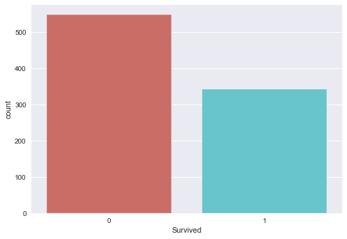

```python
sns.countplot(x = 'Survived', data = df, palette= 'hls')    # palette for setting color
```

### Checking for missing values

```python
df.isnull().sum()
```

```
PassengerId      0
Survived         0
Pclass           0
Name             0
Sex              0
Age            177
SibSp            0
Parch            0
Ticket           0
Fare             0
Cabin          687
Embarked         2
dtype: int64
```

```python
df.describe()
```

|  | PassengerId | Survived | Pclass | Age | SibSp | Parch | Fare |
| --- | --- | --- | --- | --- | --- | --- | --- |
| count | 891.000000 | 891.000000 | 891.000000 | 714.000000 | 891.000000 | 891.000000 | 891.000000 |
| mean | 446.000000 | 0.383838 | 2.308642 | 29.699118 | 0.523008 | 0.381594 | 32.204208 |
| std | 257.353842 | 0.486592 | 0.836071 | 14.526497 | 1.102743 | 0.806057 | 49.693429 |
| min | 1.000000 | 0.000000 | 1.000000 | 0.420000 | 0.000000 | 0.000000 | 0.000000 |
| 25% | 223.500000 | 0.000000 | 2.000000 | 20.125000 | 0.000000 | 0.000000 | 7.910400 |
| 50% | 446.000000 | 0.000000 | 3.000000 | 28.000000 | 0.000000 | 0.000000 | 14.454200 |
| 75% | 668.500000 | 1.000000 | 3.000000 | 38.000000 | 1.000000 | 0.000000 | 31.000000 |
| max | 891.000000 | 1.000000 | 3.000000 | 80.000000 | 8.000000 | 6.000000 | 512.329200 |

### Taking care of missing values

##### Dropping missing values

So let's just go ahead and drop all the variables that aren't relevant for predicting survival. We should at least keep the following:

- Survived - This variable is obviously relevant.
- Pclass - Does a passenger's class on the boat affect their survivability?
- Sex - Could a passenger's gender impact their survival rate?
- Age - Does a person's age impact their survival rate?
- SibSp - Does the number of relatives on the boat (that are siblings or a spouse) affect a person survivability? Probability
- Parch - Does the number of relatives on the boat (that are children or parents) affect a person survivability? Probability
- Fare - Does the fare a person paid effect his survivability? Maybe - let's keep it.
- Embarked - Does a person's point of embarkation matter? It depends on how the boat was filled... Let's keep it.

What about a person's name, ticket number, and passenger ID number? They're irrelavant for predicting survivability. And as you recall, the cabin variable is almost all missing values, so we can just drop all of these.

```python
titanic_data = df.drop(['Name', 'Ticket', 'Cabin', 'PassengerId'], axis=1)
titanic_data
```

|  | Survived | Pclass | Sex | Age | SibSp | Parch | Fare | Embarked |
| --- | --- | --- | --- | --- | --- | --- | --- | --- |
| 0 | 0 | 3 | male | 22.0 | 1 | 0 | 7.2500 | S |
| 1 | 1 | 1 | female | 38.0 | 1 | 0 | 71.2833 | C |
| 2 | 1 | 3 | female | 26.0 | 0 | 0 | 7.9250 | S |
| 3 | 1 | 1 | female | 35.0 | 1 | 0 | 53.1000 | S |
| 4 | 0 | 3 | male | 35.0 | 0 | 0 | 8.0500 | S |
| ... | ... | ... | ... | ... | ... | ... | ... | ... |
| 886 | 0 | 2 | male | 27.0 | 0 | 0 | 13.0000 | S |
| 887 | 1 | 1 | female | 19.0 | 0 | 0 | 30.0000 | S |
| 888 | 0 | 3 | female | NaN | 1 | 2 | 23.4500 | S |
| 889 | 1 | 1 | male | 26.0 | 0 | 0 | 30.0000 | C |
| 890 | 0 | 3 | male | 32.0 | 0 | 0 | 7.7500 | Q |

891 rows × 8 columns

### Handling Missing Values

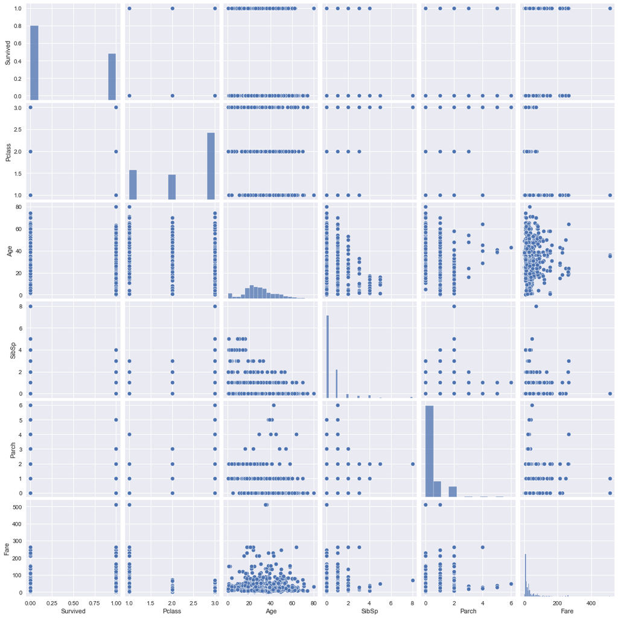

```python
sns.pairplot(titanic_data)
```

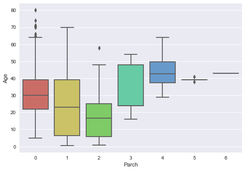

```python
sns.boxplot(x = 'Parch', y = 'Age', data = titanic_data, palette='hls')

# This plot is a box plot that shows the relationship between two variables, "Parch" and "Age". It provides information
# about the distribution of the "Age" variable for each value of the "Parch" variable and allows us to compare the spread and central tendencies
# of the "Age" data between different "Parch" groups. For example, people travelling alone are mostly aged between 22 to 39 between 22 to 40 years.
```

```python
parch__grps = titanic_data.groupby('Parch').mean()
parch__grps
```

| Parch | Survived | Pclass | Age | SibSp | Fare |
| --- | --- | --- | --- | --- | --- |
| 0 | 0.343658 | 2.321534 | 32.178503 | 0.237463 | 25.586774 |
| 1 | 0.550847 | 2.203390 | 24.422000 | 1.084746 | 46.778180 |
| 2 | 0.500000 | 2.275000 | 17.216912 | 2.062500 | 64.337604 |
| 3 | 0.600000 | 2.600000 | 33.200000 | 1.000000 | 25.951660 |
| 4 | 0.000000 | 2.500000 | 44.500000 | 0.750000 | 84.968750 |
| 5 | 0.200000 | 3.000000 | 39.200000 | 0.600000 | 32.550000 |
| 6 | 0.000000 | 3.000000 | 43.000000 | 1.000000 | 46.900000 |

```python
calculated_age = []

for i in titanic_data.index:
    if pd.isnull(titanic_data.Age[i]):
        if titanic_data.Parch[i] == 0:
            calculated_age.append(32)
        elif titanic_data.Parch[i] == 1:
            calculated_age.append(24)
        elif titanic_data.Parch[i] == 2:
            calculated_age.append(17)
        elif titanic_data.Parch[i] == 3:
            calculated_age.append(33)
        elif titanic_data.Parch[i] == 4:
            calculated_age.append(44)
        elif titanic_data.Parch[i] == 5:
            calculated_age.append(39)
        elif titanic_data.Parch[i] == 6:
            calculated_age.append(43)
    else:
        calculated_age.append(titanic_data.Age[i])

titanic_data.Age = calculated_age
```

```python
titanic_data.isnull().sum()
```

```
Survived    0
Pclass      0
Sex         0
Age         0
SibSp       0
Parch       0
Fare        0
Embarked    2
dtype: int64
```

```python
titanic_data.dropna(inplace=True)
titanic_data.reset_index(inplace=True, drop=True)
titanic_data.info()
```

```
<class 'pandas.core.frame.DataFrame'>
RangeIndex: 889 entries, 0 to 888
Data columns (total 8 columns):
 #   Column    Non-Null Count  Dtype
---  ------    --------------  -----
 0   Survived  889 non-null    int64
 1   Pclass    889 non-null    int64
 2   Sex       889 non-null    object
 3   Age       889 non-null    float64
 4   SibSp     889 non-null    int64
 5   Parch     889 non-null    int64
 6   Fare      889 non-null    float64
 7   Embarked  889 non-null    object
dtypes: float64(2), int64(4), object(2)
memory usage: 55.7+ KB
```

### Converting categorical variables to a dummy indicators

```python
titanic_data.select_dtypes(include='object').columns
```

```
Index(['Sex', 'Embarked'], dtype='object')
```

```python
from sklearn.preprocessing import LabelEncoder
Label_encoder = LabelEncoder()
titanic_data['male_gender'] = Label_encoder.fit_transform(titanic_data['Sex'])
# titanic_data['Embark_encoded'] = Label_encoder.fit_transform(titanic_data['Embarked'])
titanic_data.head()
```

|  | Survived | Pclass | Sex | Age | SibSp | Parch | Fare | Embarked | male_gender |
| --- | --- | --- | --- | --- | --- | --- | --- | --- | --- |
| 0 | 0 | 3 | male | 22.0 | 1 | 0 | 7.2500 | S | 1 |
| 1 | 1 | 1 | female | 38.0 | 1 | 0 | 71.2833 | C | 0 |
| 2 | 1 | 3 | female | 26.0 | 0 | 0 | 7.9250 | S | 0 |
| 3 | 1 | 1 | female | 35.0 | 1 | 0 | 53.1000 | S | 0 |
| 4 | 0 | 3 | male | 35.0 | 0 | 0 | 8.0500 | S | 1 |

```python
# Convert Embark_encoded to binary feature

from sklearn.preprocessing import OneHotEncoder

encoder = OneHotEncoder(categories='auto')
onehot = encoder.fit_transform(titanic_data[['Embarked']]).toarray()            # converting it to an array using toarrya() is very important

# The .toarray() method is used to convert the sparse matrix output of the fit_transform method into a dense array.
# The one-hot encoding results in a large number of columns (equal to the number of categories in the 'Embarked' column),
# so in many cases, the majority of the entries in the encoding result will be zeros. When dealing with sparse matrices,
# it is more memory efficient to store only the non-zero entries. By using the .toarray() method, the sparse matrix is converted into a dense array,
# where every entry is stored. This is usually required when using the encoding result with machine learning algorithms that cannot handle sparse matrices.
```

```python
# Create a new dataframe from the transformed data
df_onehot = pd.DataFrame(data = onehot, columns = encoder.get_feature_names(['Embarked']))
df_onehot.head()
```

|  | Embarked_C | Embarked_Q | Embarked_S |
| --- | --- | --- | --- |
| 0 | 0.0 | 0.0 | 1.0 |
| 1 | 1.0 | 0.0 | 0.0 |
| 2 | 0.0 | 0.0 | 1.0 |
| 3 | 0.0 | 0.0 | 1.0 |
| 4 | 0.0 | 0.0 | 1.0 |

```python
titanic_data.drop(['Sex', 'Embarked'], axis = 1, inplace= True)
```

```python
titanic_dmy = pd.concat([titanic_data, df_onehot], axis = 1, verify_integrity=True).astype(float)
titanic_dmy.head()

# the verify_integrity argument is set to True to verify that there are no overlapping columns in the two dataframes
```

|  | Survived | Pclass | Age | SibSp | Parch | Fare | male_gender | Embarked_C | Embarked_Q | Embarked_S |
| --- | --- | --- | --- | --- | --- | --- | --- | --- | --- | --- |
| 0 | 0.0 | 3.0 | 22.0 | 1.0 | 0.0 | 7.2500 | 1.0 | 0.0 | 0.0 | 1.0 |
| 1 | 1.0 | 1.0 | 38.0 | 1.0 | 0.0 | 71.2833 | 0.0 | 1.0 | 0.0 | 0.0 |
| 2 | 1.0 | 3.0 | 26.0 | 0.0 | 0.0 | 7.9250 | 0.0 | 0.0 | 0.0 | 1.0 |
| 3 | 1.0 | 1.0 | 35.0 | 1.0 | 0.0 | 53.1000 | 0.0 | 0.0 | 0.0 | 1.0 |
| 4 | 0.0 | 3.0 | 35.0 | 0.0 | 0.0 | 8.0500 | 1.0 | 0.0 | 0.0 | 1.0 |

### Checking for independence between features

##### Logistic Regression expects the inputs are independent

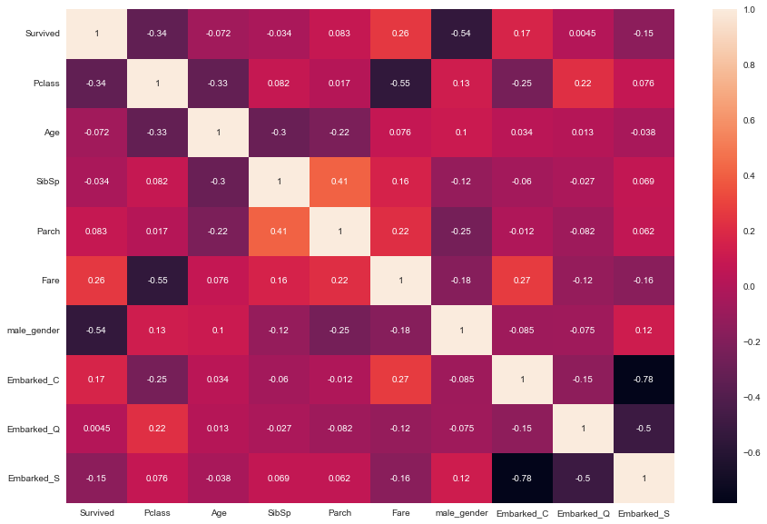

```python
plt.figure(figsize=(15,10))
sns.heatmap(titanic_dmy.corr(), annot=True)
plt.show()


# Here we can see, Pclass and Fare are negatively corelated. So we shouldnt include these features to our model. 'Survived' is the target column.
```

```python
# titanic_dmy.drop(['Pclass', 'Fare'], inplace = True, axis = 1)
titanic_dmy.drop(['Fare'], inplace = True, axis = 1)
titanic_dmy.head()
```

|  | Survived | Pclass | Age | SibSp | Parch | male_gender | Embarked_C | Embarked_Q | Embarked_S |
| --- | --- | --- | --- | --- | --- | --- | --- | --- | --- |
| 0 | 0.0 | 3.0 | 22.0 | 1.0 | 0.0 | 1.0 | 0.0 | 0.0 | 1.0 |
| 1 | 1.0 | 1.0 | 38.0 | 1.0 | 0.0 | 0.0 | 1.0 | 0.0 | 0.0 |
| 2 | 1.0 | 3.0 | 26.0 | 0.0 | 0.0 | 0.0 | 0.0 | 0.0 | 1.0 |
| 3 | 1.0 | 1.0 | 35.0 | 1.0 | 0.0 | 0.0 | 0.0 | 0.0 | 1.0 |
| 4 | 0.0 | 3.0 | 35.0 | 0.0 | 0.0 | 1.0 | 0.0 | 0.0 | 1.0 |

### Checking that the dataset size is sufficient and Splitting the data in train test set

```python
# Logistic regression expects atleast 50 records per feature. Since we have 6 features (Embarked C, S, Q are one feature)
# we should have atleast 300 records

titanic_dmy.info()

# we have 889 entries
```

```
<class 'pandas.core.frame.DataFrame'>
RangeIndex: 889 entries, 0 to 888
Data columns (total 9 columns):
 #   Column       Non-Null Count  Dtype
---  ------       --------------  -----
 0   Survived     889 non-null    float64
 1   Pclass       889 non-null    float64
 2   Age          889 non-null    float64
 3   SibSp        889 non-null    float64
 4   Parch        889 non-null    float64
 5   male_gender  889 non-null    float64
 6   Embarked_C   889 non-null    float64
 7   Embarked_Q   889 non-null    float64
 8   Embarked_S   889 non-null    float64
dtypes: float64(9)
memory usage: 62.6 KB
```

```python
X_train, X_test, y_train, y_test = train_test_split(titanic_dmy.drop('Survived', axis = 1),
                                                    titanic_dmy['Survived'], test_size=0.2, random_state=200)       # random state for splitting the traint test data in the same way everytime (not important)
```

```python
print(X_train.shape)
print(y_train.shape)
```

```
(711, 8)
(711,)
```

```python
X_train.head()
```

|  | Pclass | Age | SibSp | Parch | male_gender | Embarked_C | Embarked_Q | Embarked_S |
| --- | --- | --- | --- | --- | --- | --- | --- | --- |
| 719 | 2.0 | 6.0 | 0.0 | 1.0 | 0.0 | 0.0 | 0.0 | 1.0 |
| 165 | 1.0 | 24.0 | 0.0 | 1.0 | 0.0 | 0.0 | 0.0 | 1.0 |
| 879 | 3.0 | 33.0 | 0.0 | 0.0 | 1.0 | 0.0 | 0.0 | 1.0 |
| 451 | 1.0 | 30.0 | 0.0 | 0.0 | 1.0 | 1.0 | 0.0 | 0.0 |
| 181 | 3.0 | 9.0 | 4.0 | 2.0 | 1.0 | 0.0 | 0.0 | 1.0 |

### Deploying and evaluating the model

```python
model = LogisticRegression(solver='liblinear')
model.fit(X_train, y_train)

print(model.get_params())

# The argument solver='liblinear' specifies the algorithm used to find the optimal coefficients for the model.
# The 'liblinear' solver is a solver for small data sets or binary classification problems.
```

```
{'C': 1.0, 'class_weight': None, 'dual': False, 'fit_intercept': True, 'intercept_scaling': 1, 'l1_ratio': None, 'max_iter': 100, 'multi_class': 'auto', 'n_jobs': None, 'penalty': 'l2', 'random_state': None, 'solver': 'liblinear', 'tol': 0.0001, 'verbose': 0, 'warm_start': False}
```

```python
# 'Optional'

# from sklearn.model_selection import GridSearchCV

# # # Prepare the parameter grid to search over
# param_grid = {'C': [0.1, 1, 10, 100],
#               'penalty': ['l1', 'l2'],
#               'solver': ['liblinear']}

# # # Create the logistic regression model
# model = LogisticRegression()

# # # Create the grid search object
# grid_search = GridSearchCV(model, param_grid, cv=5, verbose = 0)

# # # Fit the grid search to the training data
# grid_search.fit(X_train, y_train)

# # # Print the best parameters and the best score
# print("Best parameters: ", grid_search.best_params_)
# print("Best score: ", grid_search.best_score_)
```

```python
y_pred = model.predict(X_test)
```

### Model Evaluation

#### Classification report without cross validation

```python
# Displaying the confusion matrix in a nice readable way

pd.DataFrame(confusion_matrix(y_test, y_pred), columns=['Predicted_No', 'Predicted_Yes'], index=['Actual_No', 'Actual_Yes'])
```

|  | Predicted_No | Predicted_Yes |
| --- | --- | --- |
| Actual_No | 100 | 9 |
| Actual_Yes | 21 | 48 |

```python
print(classification_report(y_test, y_pred))

# The higher the f1 score the better the model performance
```

```
              precision    recall  f1-score   support

         0.0       0.83      0.92      0.87       109
         1.0       0.84      0.70      0.76        69

    accuracy                           0.83       178
   macro avg       0.83      0.81      0.82       178
weighted avg       0.83      0.83      0.83       178
```

A classification report is a summary of the performance of a classification model, including precision, recall, f1-score, and support. Precision measures the proportion of correct positive predictions, (True Positive / True Positive + False Positive) recall measures the proportion of positive cases that were correctly identified, (True Positive / Total Positive) f1-score is the harmonic mean of precision and recall, and support is the number of samples of the true response that lie in that class.

### K-fold cross-validation & confusion matrices

```python
y_train_pred = cross_val_predict(model, X_train, y_train, cv = 5)

confusion_matrix(y_train, y_train_pred)
```

```
array([[382,  58],
       [ 91, 180]])
```

```python
# Displaying the confusion matrix in a nice readable way

pd.DataFrame(confusion_matrix(y_train, y_train_pred), columns=['Predicted_No', 'Predicted_Yes'], index=['Actual_No', 'Actual_Yes'])
```

|  | Predicted_No | Predicted_Yes |
| --- | --- | --- |
| Actual_No | 382 | 58 |
| Actual_Yes | 91 | 180 |

```python
precision_score(y_train, y_train_pred)
```

```
0.7563025210084033
```

### Testing a single entry

```python
titanic_dmy[863:864]
```

|  | Survived | Pclass | Age | SibSp | Parch | male_gender | Embarked_C | Embarked_Q | Embarked_S |
| --- | --- | --- | --- | --- | --- | --- | --- | --- | --- |
| 863 | 1.0 | 2.0 | 42.0 | 0.0 | 0.0 | 0.0 | 0.0 | 0.0 | 1.0 |

```python
test_passenger = np.array([2, 42, 0, 0, 0, 0, 0, 1]).reshape(1,-1)

print(model.predict(test_passenger))
print(model.predict_proba(test_passenger))
```

```
[1.]
[[0.27476411 0.72523589]]
```